# NxtIRF: 1 - Generating a Reference

Alex Chit Hei Wong

2021-03-02

NxtIRF needs to generate a set of reference files in order to perform downstream applications including running the IRFinder algorithm, collating these output files into an experiment, and drawing visualisation tools. This vignette will show how to generate a reference using either the command-line interface, or the graphics user interface (GUI).

# Command Line Interface

First, load the NxtIRF package:

```r
library(NxtIRF)
```

Next, assign or create a reference directory

```r
if(!dir.exists("Reference")) dir.create("Reference")
reference_path = "./Reference"
```

NxtIRF can source Ensembl’s gene FASTA and GTF data from the AnnotationHub’s repository. We will demonstrate how to find the desired annotation and generate a reference using the human hg38 Ensembl reference (version 94).

```r
library(AnnotationHub)
ah = AnnotationHub()
ah.options = query(ah, c("Homo Sapiens", "Ensembl", "release-94"))
```

The `query()` function from `AnnotationHub` allows one to find the relevant annotation using a vector of keywords. The above query looks for all records with “Homo Sapiens”, “Ensembl” and “release-94” in any of the fields. To view the list of queried records:

```r
ah.options
```

Note that AnnotationHub stores FASTA records as 2bit files. These are compressed FASTA files that we can use. We note that “AH65745” is the primary assembly FASTA, and that “AH64631” is the desired GTF file. We note down these records as below:

```r
ah_genome = "AH65745"
ah_transcriptome = "AH64631"
```

Then, we are ready to build the NxtIRF Reference. Run the following command:

```r
BuildReference(
    ah_genome = ah_genome,
    ah_transcriptome = ah_transcriptome,
    reference_path = reference_path,
    genome_type = "hg38")
```

Note that by setting `genome_type = "hg38"`, we are telling NxtIRF to set the default `nonPolyARef` and `MappabilityRef` using the included reference files with the `NxtIRF` package.

For more details, see `?BuildReference`

# User-supplied FASTA and GTF files

Alternatively, NxtIRF accepts user-supplied FASTA and GTF files. Below, we demonstrate how to build the same reference but using the mouse mm10 default `nonPolyARef` and `MappabilityRef` files:

```r
fasta = "genome.fa"
gtf = "transcripts.gtf"

BuildReference(
    fasta = fasta,
    gtf = gtf,
    genome_type = "mm10"
)
```

# Generating a custom Mappability Exclusion (ME) file

## 1) Generate Mappability Reads

```r
run_IRFinder_GenerateMapReads(
    genome.fa = "genome.fa",
    out.fa = "mappability_reads.fa",
    read_len = 70,
    read_stride = 10,
    error_pos = 35
)
```

This step generates a systematic set of reads using the supplied genome FASTA file. `read_len` specifies the length of reads being generated, `read_stride` specifies how many nucleotides to increment along the genome for each read (which are generated alternately using positive / negative strand), and `error_pos` is the position in each read to systematically generate a single nucleotide error. This emulates the procedure of the original IRFinder, in place of the original PERL scripts used to calculate mappability.

## 2) Align reads to the genome

The resulting output file `mappability_reads.fa` needs to be aligned back to the same genome. Below is an example of how to use `STAR` to align the reads. We assume a STAR reference for the same genome has already been built. The following code needs to be run on linux command-line:

```bash
STAR \
    --genomeDir "./STAR_Reference" \
    --genomeLoad NoSharedMemory \
    --runThreadN 8 \
    --outStd SAM \
    --outSAMmode NoQS \
    --outSAMattributes None \
    --outFilterNultimapNmax 1 \
    --readFilesIn "mappability_reads.fa" \
    > "Aligned.bam"
```

## 3) Process aligned reads to evaluate low mappability regions

The final step involves evaluating the aligned reads to identify regions of low mappability. NxtIRF evaluates this as follows:

```r
run_IRFinder_MapExclusionRegions(
    bamfile = "Aligned.bam",
    output_file = "MappabilityExclusion.bed",
    threshold = 4,
    includeCov = FALSE
)
```

The above command will output to `MappabilityExclusion.bed` any region with a coverage of 4 or less. Note that if the region is uniquely covered, we expect a coverage of 7 (with 70-nt reads of 10 nt stride, we expect 7 reads of coverage per base).

We can then generate the NxtIRF reference using the custom ME file as below:

```r
fasta = "genome.fa"
gtf = "transcripts.gtf"
MappabilityRef = "MappabilityExclusion.bed"

BuildReference(
    fasta = fasta,
    gtf = gtf,
    genome_type = "",
    MappabilityRef = MappabilityRef
)
```

NB: If using custom `MappabilityRef` or `nonPolyARef`, make sure to set `genome_type = ""`.

# Graphics User Interface

Start the GUI using the following:

```r
library(NxtIRF)
nxtIRF()
```

[figure not shown]

Title page

Next, navigate to the `Reference` tab:

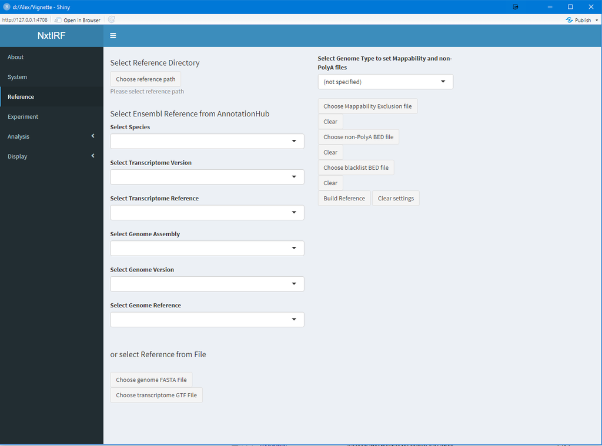

Reference

Clicking on the `Choose Reference Path` to choose a reference path. A dialog box will pop up. Select the working directory (which is the directory set by setwd(). Click “Create new folder” and type in “Reference” to create this folder in the highlighted path

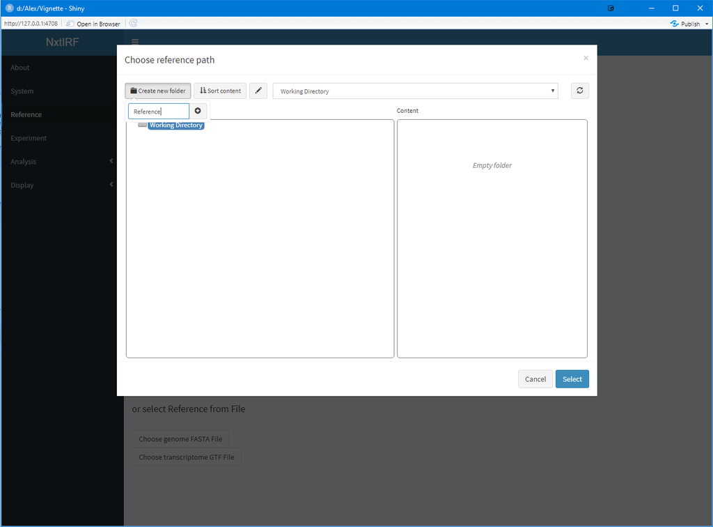

Create a new folder for the Reference

Now, select the path to the created reference folderon the left hand box, and click “Select”:

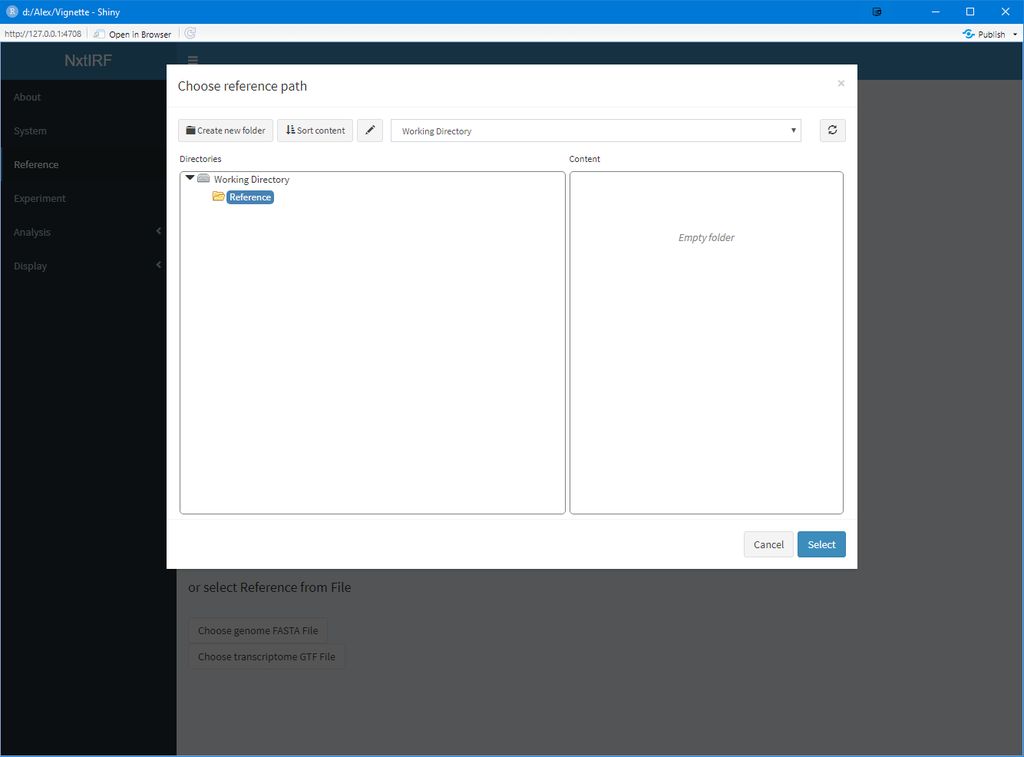

Select Reference path dialog box

Next, we can navigate AnnotationHub’s Ensembl database for the Homo Sapiens release-94 FASTA and GTF files. First, type in `Homo Sapiens` to filter for species:

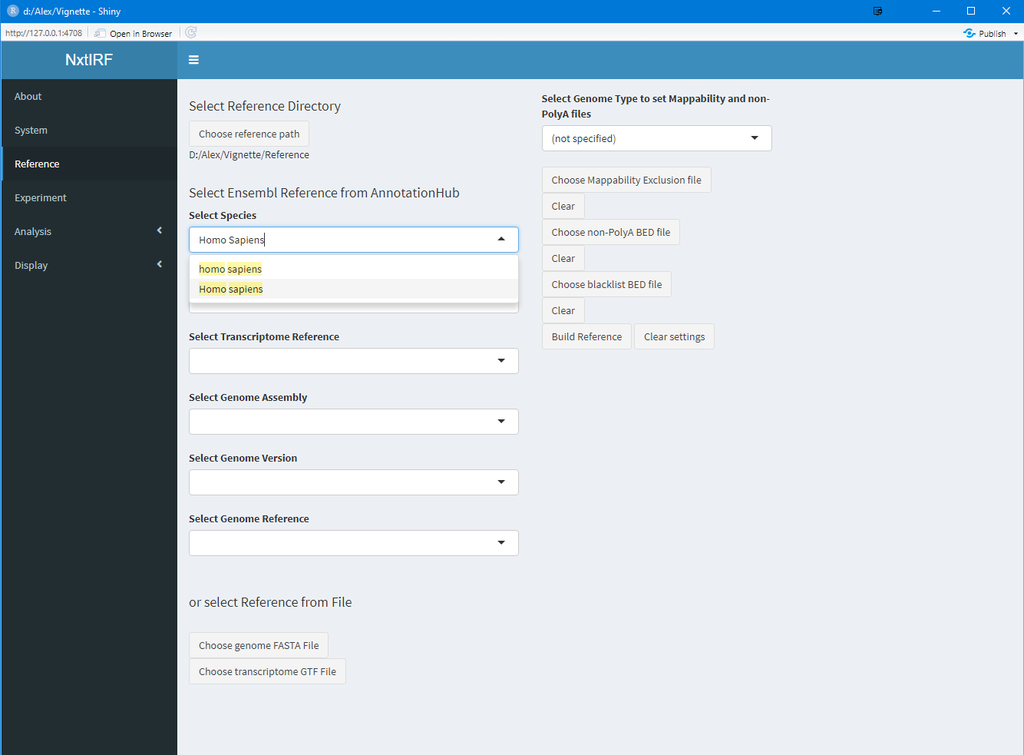

Select species

The next drop-down box will be auto-filled using the filtered options. Select `release-94` to filter for transcriptome GTF annotations belonging to this release:

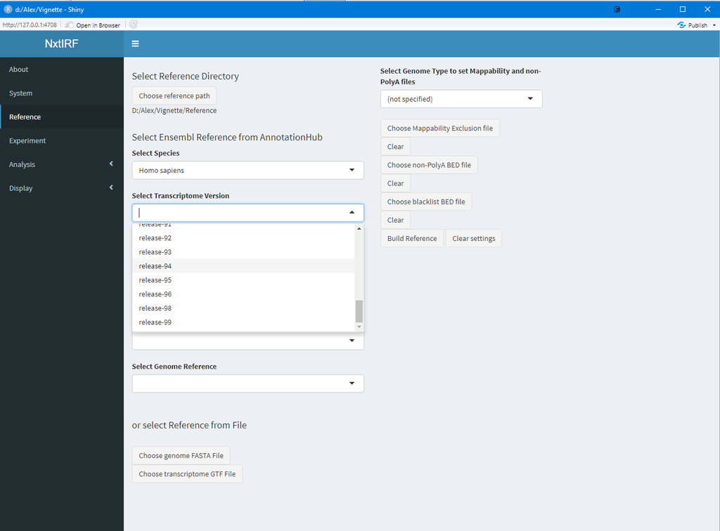

Select Ensembl release

Next, select the correct GTF file:

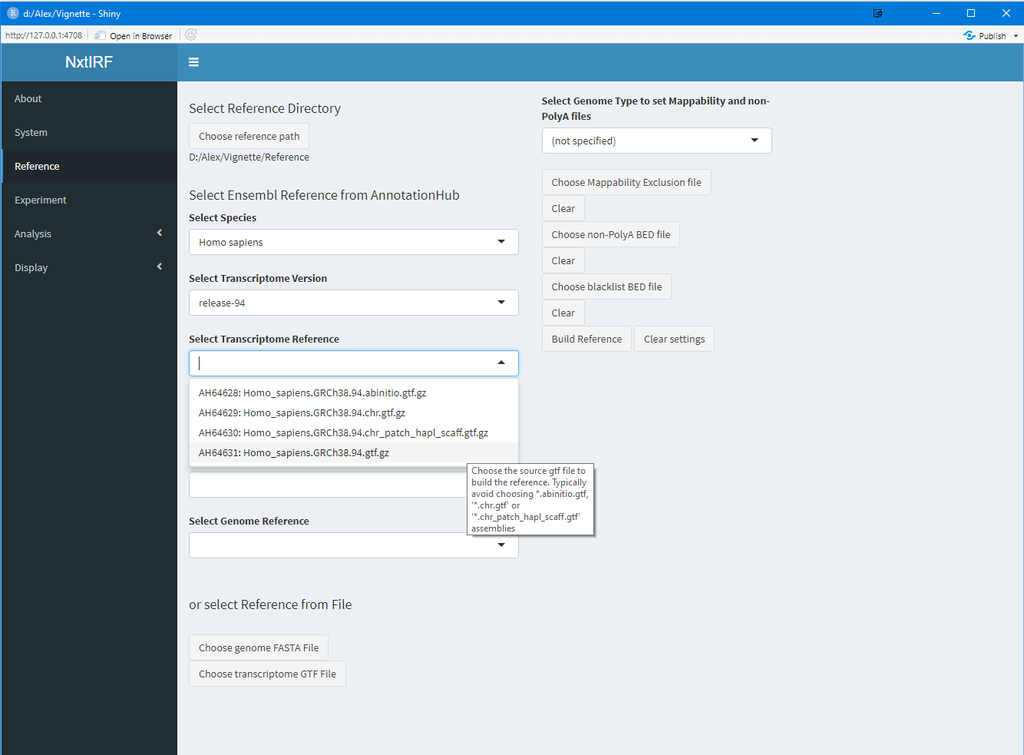

Select GTF file

The FASTA files can be chosen. NxtIRF automatically filters for all genome files compatible with the chosen GTF file. We select the FASTA file from the same release as shown:

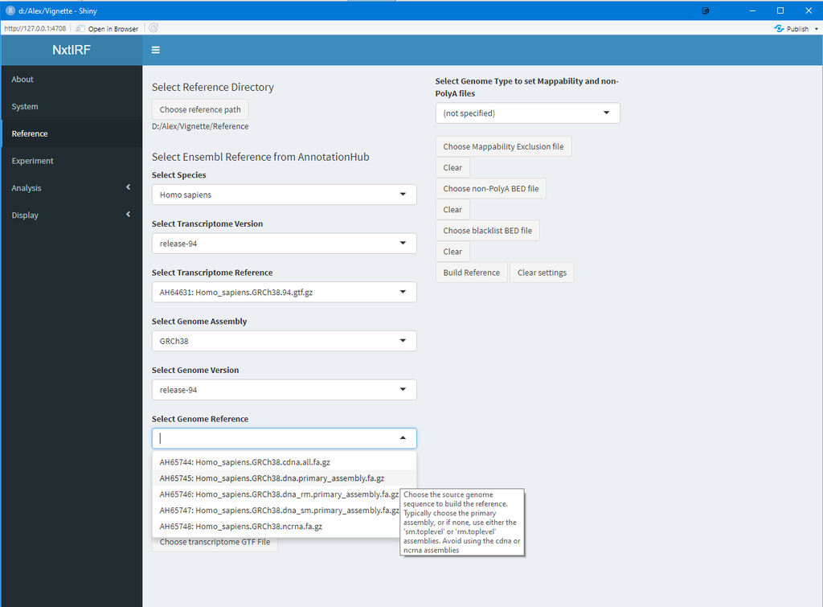

Select FASTA file

Note that the user can select their own FASTA and GTF files (see below). In this case, leave the AnnotationHub settings blank:

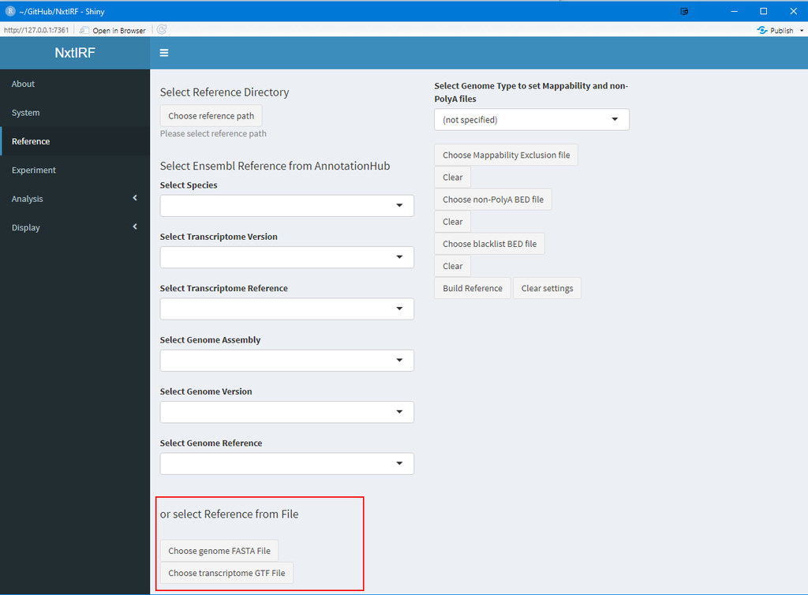

Supply custom FASTA/GTF files

Finally, set the genome defaults for Mappability Exclusion and non- PolyA BED files using the genome drop-down box:

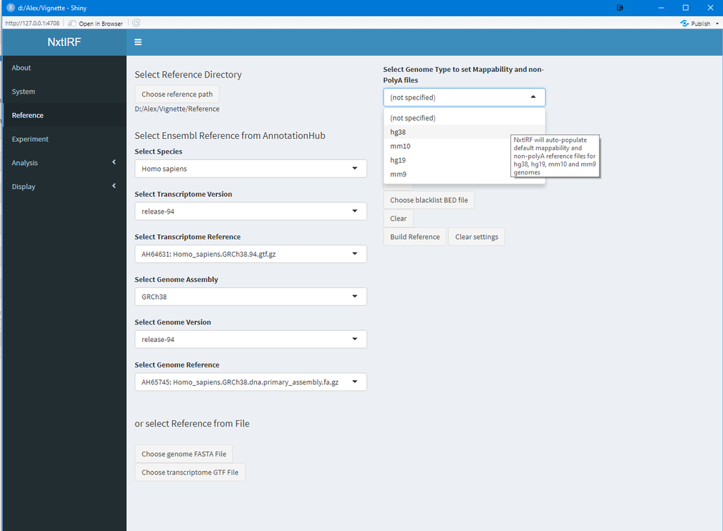

Select defaults for hg38

Note that the below fields auto-populate to system-supplied defaults:

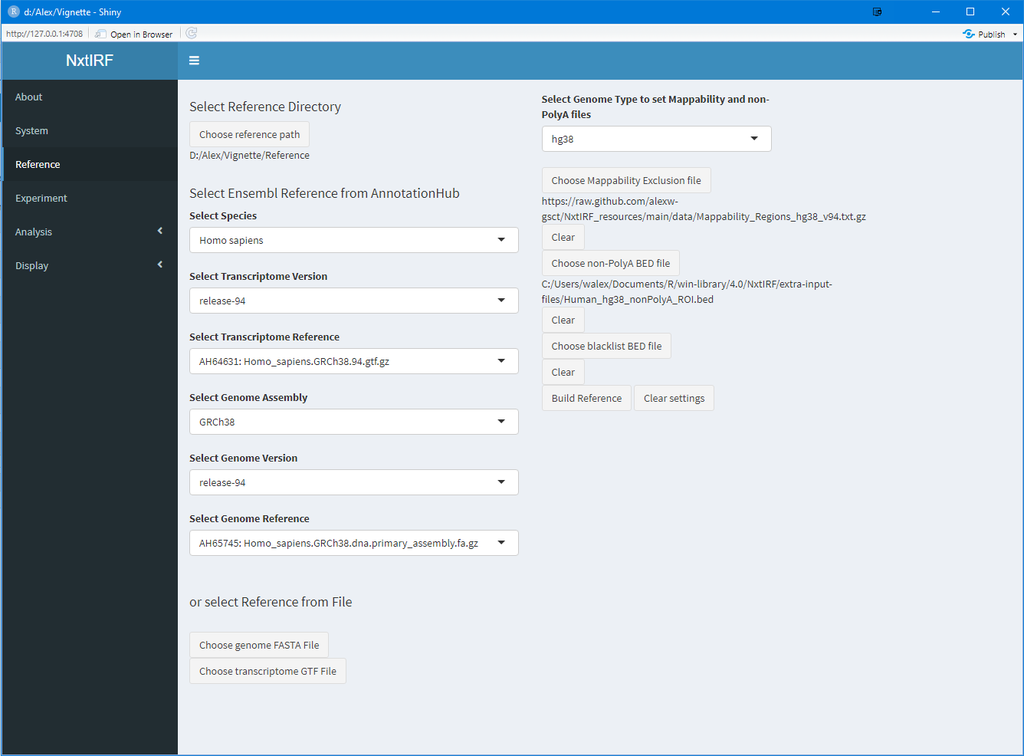

Ready to run Reference

The last step is to click the `Build Reference` button at the bottom-right area. Note that the progress can be seen in the bottom-right corner:

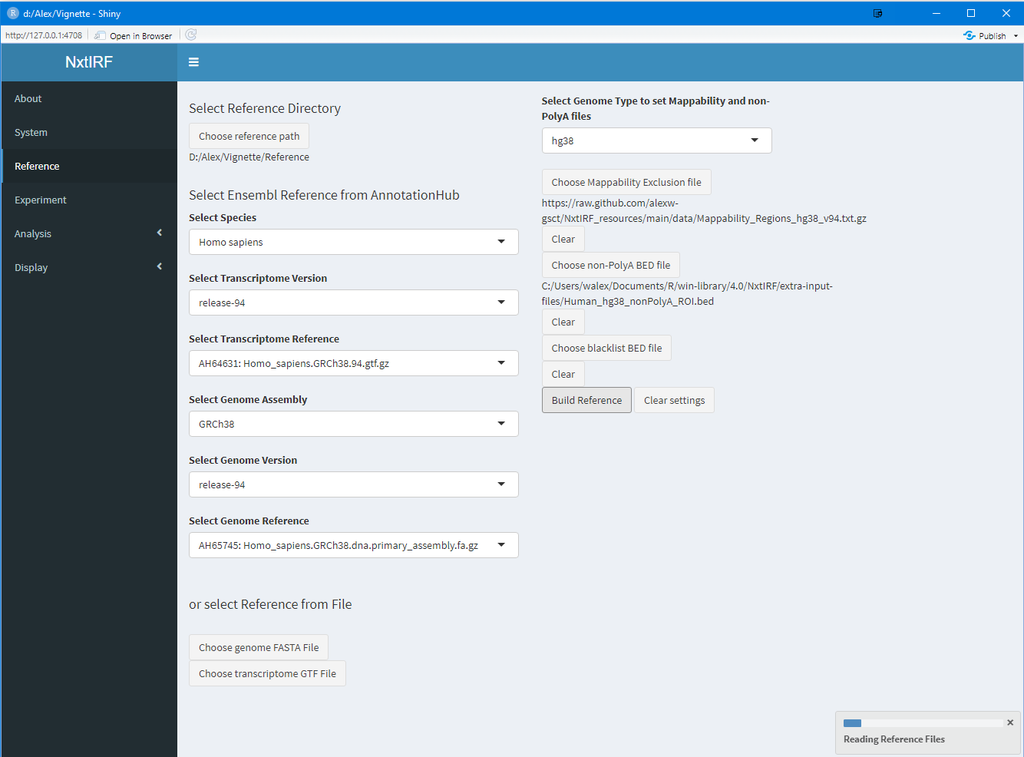

Running BuildReference

When this is completed:

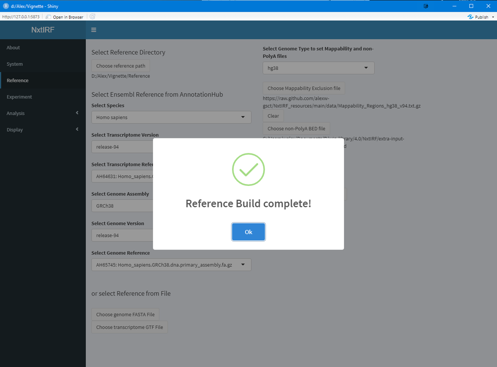

Reference build complete

Now you are ready to process the experiment!